# Relatório de Processamento de Dados - Projeto Castanhão

Modelo de Clorofila

Carlos Antônio Zarzar

10/08/2025

## 1. Introdução

Este relatório descreve o processamento de dados realizado para o Projeto Castanhão, com foco na construção de um modelo para análise da clorofila em função de variáveis ambientais. O objetivo principal foi consolidar dados de múltiplas planilhas Excel contendo informações sobre:

- Clorofila-a
- Nitrogênio Total
- Fósforo Total
- Turbidez
- Precipitação

## 2. Metodologia

### 2.1. Carregamento de Pacotes e Preparação do Ambiente

```r
#### Projeto Castanhão - Paulo - Modelo Clorofila
# Data: 10/08/2025
# Autor: Carlos Antônio Zarzar
#-------------------------------------------------------------------------------
# Objetivo:
# Juntar os dados de clorofila, Nitrogênio total, Posforo total, Turbidez, profundidade, Precipitação

#-------------------------------------------------------------------------------
# Pacotes
library(readxl)
library(dplyr)
library(lubridate)

# Limpando área de trabalho
rm(list = ls())
```

### 2.2. Importação dos Dados

Os dados foram importados de dois arquivos Excel principais: - `Dados Castanhão.xlsx` (contendo 4 planilhas diferentes) - `Precipitação.xlsx`

```r
# Importando dados
df_chl <- read_xlsx("Dados Castanhão.xlsx", sheet = "Clorofila a ")
df_nt <- read_xlsx("Dados Castanhão.xlsx", sheet = "Nitrogênio Total")
df_pt <- read_xlsx("Dados Castanhão.xlsx", sheet = "Fósforo Total")
df_turb <- read_xlsx("Dados Castanhão.xlsx", sheet = "Turbidez")
df_precip <- read_xlsx("Precipitação.xlsx", sheet = "Precipitação")
df_precip$Precipitação <- as.numeric(df_precip$Precipitação)
```

**Observação:** Foram detectados valores NA na conversão da coluna Precipitação.

### 2.3. Padronização das Colunas

Definiu-se um conjunto padrão de colunas para todos os data frames:

```r
# Colunas desejadas
colunas_desejadas <- c("CAMPANHA","PONTO","PROF","DATA_COLETA","HORARIO","RESULTADO","DESCR_PONTO")

# Lista com os data frames originais
lista_df <- list(
  df_chl = df_chl,
  df_nt = df_nt,
  df_pt = df_pt,
  df_turb = df_turb
)

# Função para selecionar as colunas (mantém só as que existem no DF)
selecionar_colunas <- function(df) {
  df[, intersect(colunas_desejadas, colnames(df)), drop = FALSE]
}

# Aplica a função a todos os data frames
lista_df <- lapply(lista_df, selecionar_colunas)
```

### 2.4. Renomeação das Colunas de Resultado

Para facilitar a identificação posterior, a coluna “RESULTADO” foi renomeada conforme o tipo de medição:

```r
# Renomeando as Colunas RESULTADO para cada Data Frame
lista_df <- list(
  chl  = df_chl,
  nt   = df_nt,
  pt   = df_pt,
  turb = df_turb
)

# Criar uma lista vazia para armazenar os data frames processados
lista_df_processada <- list()

# Loop sobre cada data frame da lista original
for (nome_df in names(lista_df)) {
  # Extrai o data frame atual da lista
  df_atual <- lista_df[[nome_df]]

  # Seleciona somente as colunas que existem tanto na lista desejada quanto no data frame atual
  colunas_presentes <- intersect(colunas_desejadas, names(df_atual))
  df_selecionado <- df_atual[, colunas_presentes, drop = FALSE]

  # Verifica se a coluna "RESULTADO" está presente para renomeá-la
  if ("RESULTADO" %in% names(df_selecionado)) {
    # Renomeia "RESULTADO" para o nome do data frame atual
    names(df_selecionado)[names(df_selecionado) == "RESULTADO"] <- nome_df
  }

  # Salva o data frame processado na lista nova
  lista_df_processada[[nome_df]] <- df_selecionado
}

# Reatribui os data frames processados para as variáveis originais
df_chl  <- lista_df_processada$chl
df_nt   <- lista_df_processada$nt
df_pt   <- lista_df_processada$pt
df_turb <- lista_df_processada$turb
```

**Resultado:** Cada data frame agora possui colunas padronizadas com a variável de interesse renomeada apropriadamente (chl, nt, pt, turb).

## 3. Análise de Consistência dos Dados

### 3.1. Verificação de Correspondência entre Datasets

```r
# Análise comparação (match)
# Dados correspondente
dados_match <- merge(
  df_chl,
  df_nt,
  by = c("CAMPANHA", "PONTO", "PROF", "DATA_COLETA")
)

# print(dados_match)
dim(dados_match)  # Resultado: [1] 330  10
```

```
## [1] 330  10
```

**Resultado:** Foram encontrados 330 registros com correspondência perfeita entre os dados de clorofila e nitrogênio total.

### 3.2. Detecção de Duplicatas

```r
# Função para detectar duplicatas
checar_duplicatas <- function(df, nome_df) {
  df %>%
    count(CAMPANHA, PONTO, PROF, DATA_COLETA) %>%
    filter(n > 1) %>%
    arrange(desc(n)) %>%
    mutate(dataframe = nome_df)
}

# Aplicar a função a todos os data frames
duplicatas <- bind_rows(
  lapply(names(lista_df), function(nome) {
    checar_duplicatas(lista_df[[nome]], nome)
  })
)
```

### 3.3. Consolidação dos Dados

```r
# Lista com todos os data frames
lista_df <- list(df_chl, df_nt, df_pt, df_turb)

# Faz o full join de todos de uma vez
dados_full <- Reduce(function(x, y) {
  full_join(x, y, by = c("CAMPANHA", "PONTO", "PROF", "DATA_COLETA"))
}, lista_df)

print(dados_full)
```

```
## # A tibble: 1,281 × 16
##    CAMPANHA PONTO   PROF DATA_COLETA         HORARIO.x             chl
##    <chr>    <chr>  <dbl> <dttm>              <dttm>              <dbl>
##  1 fev/2013 CTN-20   0.3 2013-02-19 00:00:00 1899-12-31 10:30:00  6.41
##  2 fev/2013 CTN-18   0.3 2013-02-19 00:00:00 1899-12-31 15:00:00  2.67
##  3 fev/2013 CTN-10   0.3 2013-02-19 00:00:00 1899-12-31 11:10:00  1
##  4 fev/2013 CTN-05   0.3 2013-02-19 00:00:00 1899-12-31 11:30:00  1
##  5 fev/2013 CTN-01   0.3 2013-02-19 00:00:00 1899-12-31 12:00:00  1
##  6 mai/2013 CTN-20   0.3 2013-05-20 00:00:00 1899-12-31 10:55:00  7.5
##  7 mai/2013 CTN-18   0.3 2013-05-20 00:00:00 1899-12-31 13:30:00  7.8
##  8 mai/2013 CTN-10   0.3 2013-05-20 00:00:00 1899-12-31 12:40:00 10.4
##  9 mai/2013 CTN-05   0.3 2013-05-20 00:00:00 1899-12-31 12:20:00  8.58
## 10 mai/2013 CTN-01   0.3 2013-05-20 00:00:00 1899-12-31 13:00:00 11.2
## # ℹ 1,271 more rows
## # ℹ 10 more variables: DESCR_PONTO.x <chr>, HORARIO.y <dttm>, nt <dbl>,
## #   DESCR_PONTO.y <chr>, HORARIO.x.x <dttm>, pt <dbl>, DESCR_PONTO.x.x <chr>,
## #   HORARIO.y.y <dttm>, turb <dbl>, DESCR_PONTO.y.y <chr>
```

```r
dim(dados_full)  # Resultado: [1] 1281   16
```

```
## [1] 1281   16
```

**Observações importantes:** - Foram detectadas relações muitos-para-muitos durante o join - O dataset consolidado possui 1.281 registros com 16 colunas

## 4. Limpeza e Filtragem dos Dados

### 4.1. Remoção de Registros sem Clorofila

```r
# Excluindo linhas que não têm dados de clorofila
num_NA <- table(is.na(dados_full$chl))
cat("Número de linhas excluídas:",num_NA["TRUE"])  # 690 linhas
```

```
## Número de linhas excluídas: 690
```

```r
df <- dados_full[!is.na(dados_full$chl), ]
dim(df)  # Resultado: [1] 591  16
```

```
## [1] 591  16
```

### 4.2. Remoção de Registros sem Variáveis Explicativas

```r
# Remove linhas onde nt, pt e turb são todos NA ao mesmo tempo
df_limpo <- df[!(is.na(df$nt) & is.na(df$pt) & is.na(df$turb)), ]
num_NA <- table((is.na(df$nt) & is.na(df$pt) & is.na(df$turb)))
cat("Número de linhas excluídas:",num_NA["TRUE"])  # 1 linha
```

```
## Número de linhas excluídas: 1
```

```r
dim(df_limpo)  # Resultado: [1] 590  16
```

```
## [1] 590  16
```

## 5. Problema Identificado: Dados Limitados de Turbidez

### 5.1. Análise da Disponibilidade de Dados de Turbidez

```r
tam_linhas <- dim(df_limpo)[1]
nao_tem_turb <- table((is.na(df_limpo$turb)))

cat("Tamanho do conjunto de dados após processamento (df_limpo):",tam_linhas)      # 590
```

```
## Tamanho do conjunto de dados após processamento (df_limpo): 590
```

```r
cat("Excluindo linhas que não tem informação da Turbidez:",nao_tem_turb["TRUE"])  # 512
```

```
## Excluindo linhas que não tem informação da Turbidez: 512
```

```r
cat("Dimensão dos dados se excluir NA da Turbidez:",tam_linhas-nao_tem_turb["TRUE"]) # 78
```

```
## Dimensão dos dados se excluir NA da Turbidez: 78
```

**Problema Crítico:** Apenas 78 registros (13,2%) possuem dados de turbidez, o que representa uma limitação significativa para a modelagem.

### 5.2. Análise Exploratória das Relações

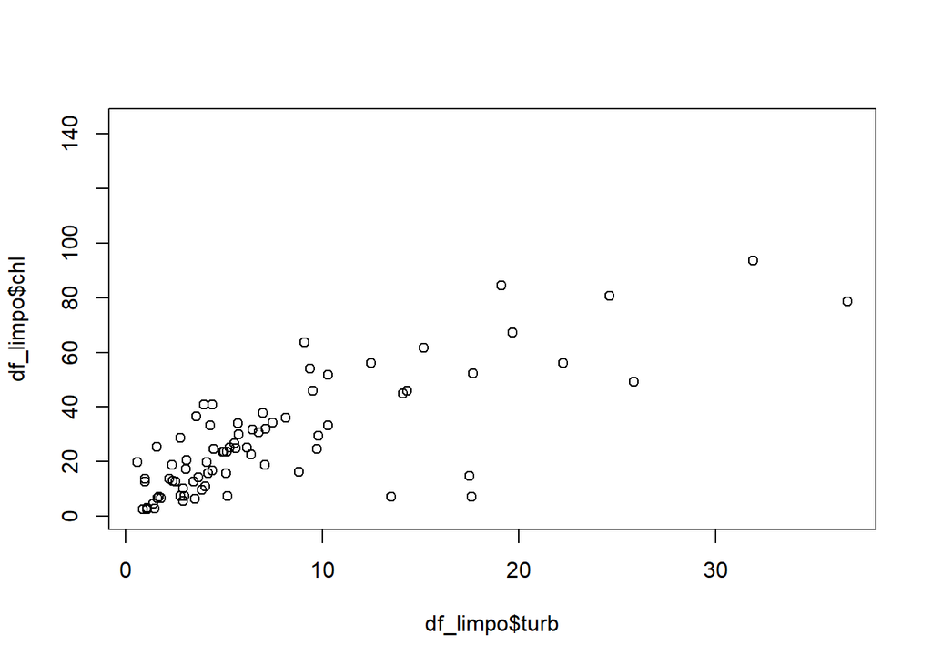

```r
# Relação da Turbidez com outras variáveis
plot(df_limpo$turb,df_limpo$chl)
```

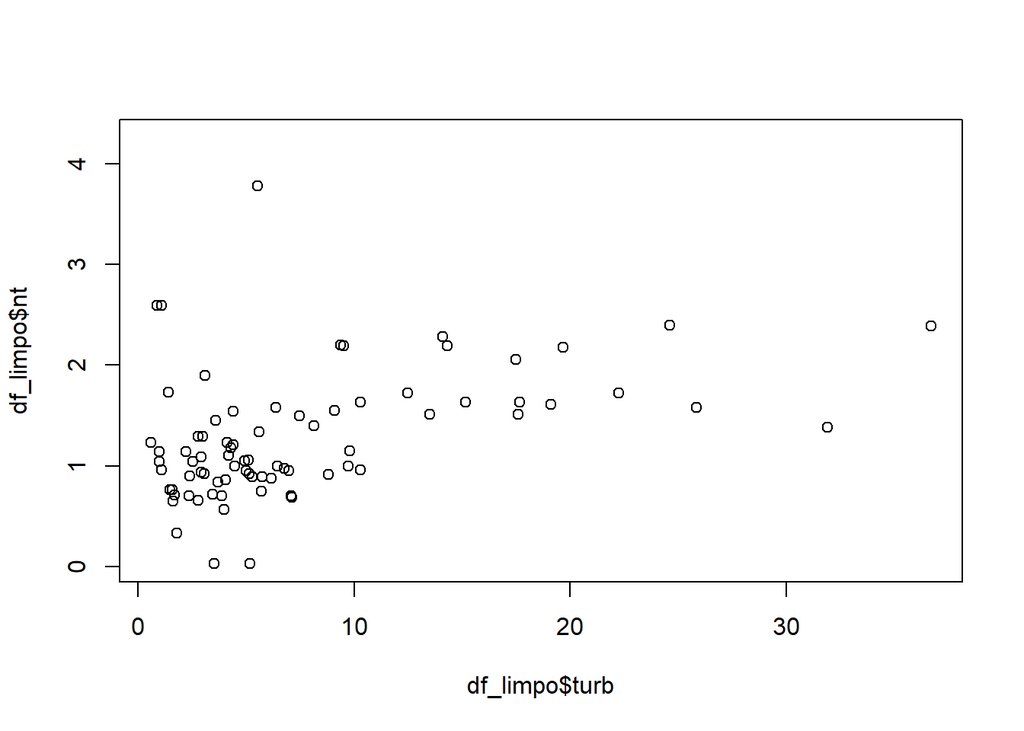

```r
plot(df_limpo$turb,df_limpo$nt)
```

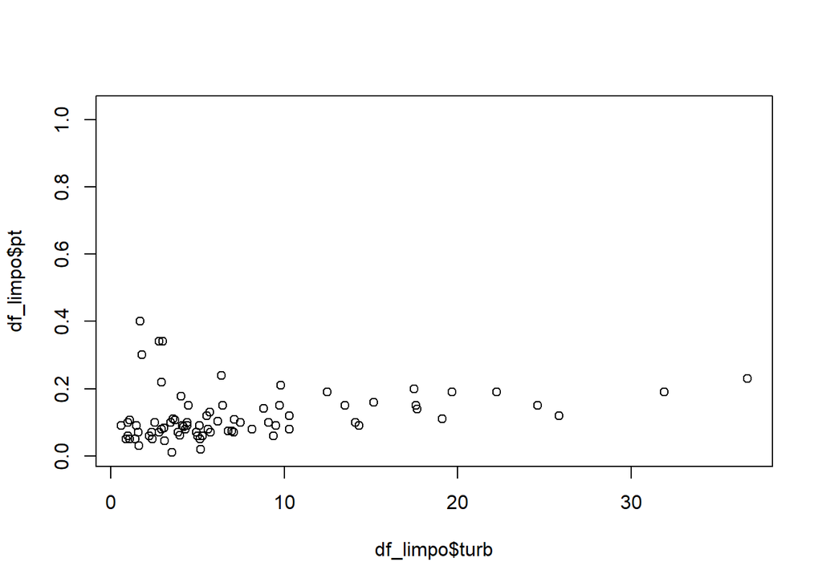

```r
plot(df_limpo$turb,df_limpo$pt)
```